Statistiques en grandes dimensions Yassine et Exaucé CMI ISI 11 Décembre 2021

# Données

Chargons les données.

```r
load("Devoir301221.RData")
data<-as_tibble(devoir201221)
paged_table(data)
```

| TDM | T | HR | PR | CL | PD | MA | SI | FM | SH |
| --- | --- | --- | --- | --- | --- | --- | --- | --- | --- |
| 214.4 | 9.05 | 61.46 | 142.08 | 0.000 | 55.41 | 40 | 36 | -16.6 | 19.3 |
| 16.1 | 24.76 | 69.99 | 155.98 | 0.049 | 98.77 | 36 | 36 | -15.0 | 27.9 |
| 214.9 | 13.19 | 77.81 | 151.43 | 0.074 | 128.55 | 40 | 43 | -1.2 | 40.8 |
| 267.8 | 3.97 | 75.17 | 150.02 | 0.044 | 53.83 | 41 | 39 | -10.0 | 16.8 |
| 166.6 | 17.10 | 73.56 | 161.80 | 0.119 | 84.64 | 40 | 44 | -16.3 | 35.9 |
| 185.6 | 14.38 | 65.67 | 143.87 | 0.000 | 81.47 | 43 | 42 | -17.6 | 29.8 |
| 250.1 | 16.53 | 85.91 | 138.33 | 0.037 | 172.92 | 41 | 32 | -9.5 | 15.8 |
| 224.4 | 9.39 | 64.54 | 157.67 | 0.021 | 95.31 | 43 | 36 | -16.6 | 19.4 |
| 340.6 | 7.44 | 75.61 | 157.90 | 0.106 | 162.00 | 38 | 34 | 0.1 | 34.9 |
| 186.1 | 11.38 | 72.44 | 165.99 | 0.142 | 59.28 | 41 | 34 | -25.5 | 32.2 |

[output cut: 45 more lines]

```r
dim(data)
```

```
## [1] 55 10
```

Nous avons 55 observations de 10 variables.

Ce format de données de type “unity” est pratique pour les modèles mais pas pour les graphiques avec *ggplot2* nous allons donc créer un nouveau dataframe sous un format tidy.

```r
data$ID <- seq.int(nrow(data))
data_m <- data %>% melt(id.var="ID")
paged_table(data_m)
```

| ID | variable | value |
| --- | --- | --- |
| 1 | TDM | 214.400 |
| 2 | TDM | 16.100 |
| 3 | TDM | 214.900 |
| 4 | TDM | 267.800 |
| 5 | TDM | 166.600 |
| 6 | TDM | 185.600 |
| 7 | TDM | 250.100 |
| 8 | TDM | 224.400 |
| 9 | TDM | 340.600 |
| 10 | TDM | 186.100 |

[output cut: 540 more lines]

## La variable réponse

- **TDM** (le nombre total des décès par million d’habitants dus au COVID-19 entre le 1/3/2020 et le 31/5/2020),

## Variables explicatives

### Climatiques

- **T** la température moyenne ( ◦ C),
- **HR** l’humidité relative moyenne (%),
- **PR** le cumul des précipitations (mm),
- **CL** la fraction de la couverture nuageuse moyenne

### Socio démographiques

- **PD** la densité de population (personnes/km2),
- **MA** l’âge médian de la population,

### Réponses des gouvernements

- **SI** l’indice de ”rigueur” (mesure composite basée sur 9 indicateurs tels que les fermetures d’écoles, les fermetures de lieux de travail, les restrictions de voyage et les confinements à domicile) moyen,
- **FM** le délai entre le 1er cas et l’imposition des 1ères mesures (jours),
- **SH** le délai entre le 1er cas et l’ordre de rester à la maison (jours).

```r
colnames(data)
```

```
##  [1] "TDM" "T"   "HR"  "PR"  "CL"  "PD"  "MA"  "SI"  "FM"  "SH"  "ID"
```

```r
var_climat<-c(2,3,4,5)
var_socio_demo<-c(6,7)
var_mes_gouv<-c(8,9,10)
```

# Analyse descriptive

## Analyse descriptive univariée

Il est important de faire une analyse de chaque variable une à une pour avoir une idée de la distribution des variables.

```r
summary(data)
```

```
##       TDM              T                HR              PR
##  Min.   : 16.1   Min.   : 0.260   Min.   :46.17   Min.   :133.8
##  1st Qu.:172.6   1st Qu.: 7.765   1st Qu.:62.84   1st Qu.:144.5
##  Median :222.8   Median :10.960   Median :69.80   Median :150.0
##  Mean   :222.2   Mean   :11.619   Mean   :69.34   Mean   :150.6
##  3rd Qu.:267.9   3rd Qu.:16.040   3rd Qu.:74.92   3rd Qu.:157.0
##  Max.   :785.4   Max.   :24.760   Max.   :96.47   Max.   :175.1
##        CL               PD               MA              SI
##  Min.   :0.0000   Min.   : 30.85   Min.   :36.00   Min.   :30.00
##  1st Qu.:0.0000   1st Qu.: 62.02   1st Qu.:38.00   1st Qu.:36.00
##  Median :0.0030   Median : 94.25   Median :40.00   Median :39.00
##  Mean   :0.0456   Mean   : 93.84   Mean   :40.62   Mean   :38.96
##  3rd Qu.:0.0690   3rd Qu.:115.26   3rd Qu.:43.00   3rd Qu.:42.00
##  Max.   :0.2830   Max.   :173.80   Max.   :48.00   Max.   :47.00
##        FM               SH              ID
##  Min.   :-32.90   Min.   :12.40   Min.   : 1.0
##  1st Qu.:-19.65   1st Qu.:23.65   1st Qu.:14.5
##  Median :-14.90   Median :34.40   Median :28.0
##  Mean   :-14.75   Mean   :35.93   Mean   :28.0
##  3rd Qu.: -9.30   3rd Qu.:43.50   3rd Qu.:41.5
##  Max.   :  1.40   Max.   :70.10   Max.   :55.0
```

On remarque des valeurs très variées qui sont dûes certainement aux unités utilisées. Visualisons cela par des boites à moustaches.

```r
theme_update(plot.title = element_text(hjust = 0.5))
```

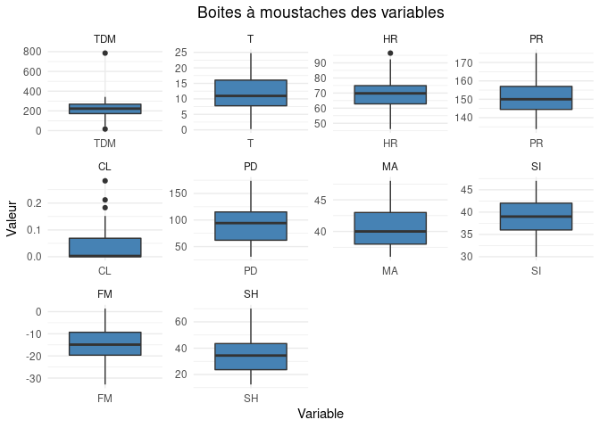

```r
theme_update(plot.title = element_text(hjust = 0.5))

ggplot(data_m) +
  aes(x = variable, y = value) +
  geom_boxplot(shape = "circle", fill = "#4682B4") +
  labs(
    x = "Variable",
    y = "Valeur",
    title = "Boites à moustaches des variables"
  ) +
  theme_minimal() +
  theme(plot.title = element_text(hjust = 0.5)) +
  facet_wrap(vars(variable), scales = "free", nrow = 3L)
```

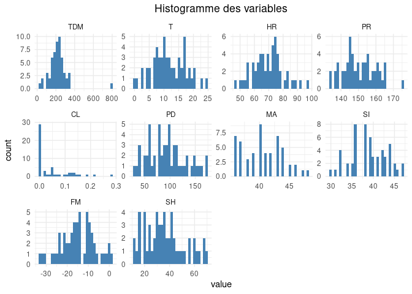

```r
ggplot(data_m) +
  aes(x = value) +
  geom_histogram(bins = 30L, fill = "#4682B4") +
  labs(title = "Histogramme des variables") +
  theme_minimal()+
  theme(plot.title = element_text(hjust = 0.5))  +
  facet_wrap(vars(variable), scales = "free", nrow = 3L)
```

Cette répresentation permet d’avir une idée sur la distribution de chaque variable et de se rendre compte de la différence d’échelle. Maintenant éudions la rélation entre les variables explicatives à travers répresentations multivariées.

## Analyses descriptives multivariées

### Variables explicatives

Nous allons étudier les rélations entre les variables explicatives afin de desceller une correlation significative.

```r
colnames(data)
```

```
##  [1] "TDM" "T"   "HR"  "PR"  "CL"  "PD"  "MA"  "SI"  "FM"  "SH"  "ID"
```

#### Variables climatiques

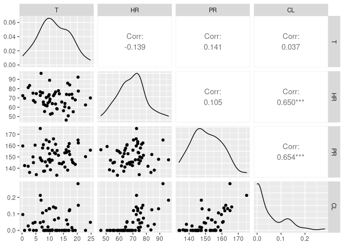

```r
ggpairs(data,columns = var_climat)
```

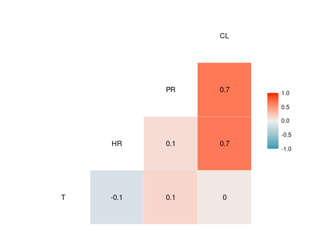

```r
ggcorr(data[var_climat], palette = "RdBu", label = TRUE)
```

On remarque les variables climatiques sont globalement très peu corrélées sauf la couverture nuageuse **CL** qui est positivement corrélée avec l’humidité relative **HR** et le cumul de pluies **PR**.

#### Variables socio-démographiques

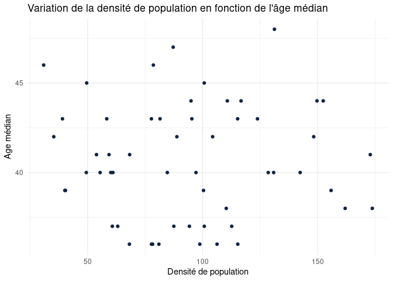

```r
ggplot(data) +
  aes(x = PD, y = MA) +
  geom_point(shape = "circle", size = 1.5, colour = "#112446") +
  labs(
    x = "Densité de population",
    y = "Age médian",
    title = "Variation de la densité de population en fonction de l'âge médian"
  ) +
  theme(plot.title = element_text(hjust = 0.5)) +
  theme_minimal()
```

On remarque à priori qu’il y a aucune corrélation linéaire entre l’âge médian et la densité de population. Nous allons vérifier cela par un test de correlation.

```r
c1<-  cor.test(data$MA, data$PD, method=c("pearson"))$estimate
p1<-  cor.test(data$MA, data$PD, method=c("pearson"))$p.value


c2<- cor.test(data$MA, data$PD, method=c("kendall"))$estimate
p2<- cor.test(data$MA, data$PD, method=c("kendall"))$p.value


c3<- cor.test(data$MA, data$PD, method=c("spearman"))$estimate
p3<- cor.test(data$MA, data$PD, method=c("spearman"))$p.value

pvalue<-c(p1,p2,p3)
cor<- c(c1,c2,c3)
```

```r
Test<-as.data.frame(rbind("estimate"= cor,"pvalue"=pvalue))
colnames(Test)<-c("pearson","kendall","spearman")
paged_table(Test)
```

|  | pearson | kendall | spearman |
| --- | --- | --- | --- |
| estimate | -0.004822613 | -0.004927482 | 0.001451483 |
| pvalue | 0.972124276 | 0.959194116 | 0.991608615 |

D’après ce test, On peut affirmer qu’il n’y a aucune correlation linéaire entre les variables socio-démographiques dont l’âge médian et la densité de population. La correlation est très faible peu importe la mesure utilisée.

#### Variables mesures gouvermentales

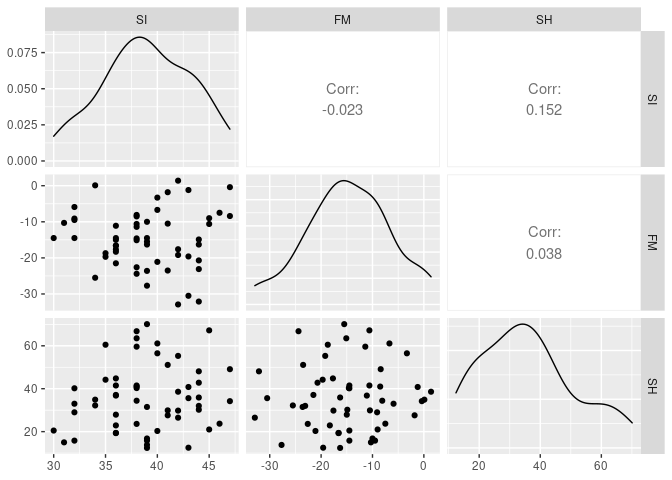

```r
ggpairs(data,columns = var_mes_gouv)
```

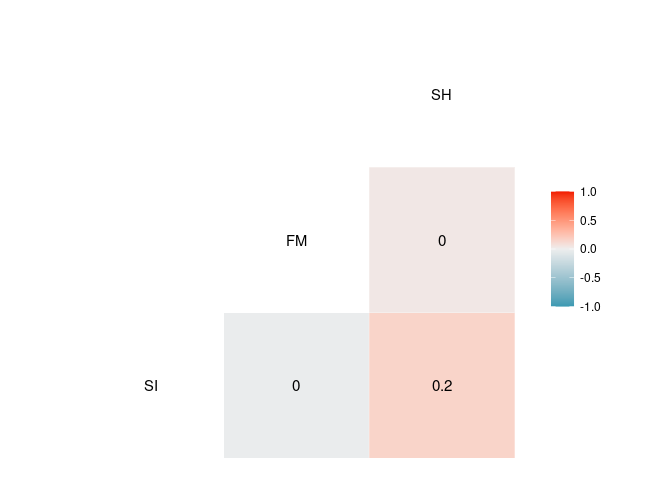

```r
ggcorr(data[var_mes_gouv], palette = "RdBu", label = TRUE)
```

Une fois de plus la correlation linéaire entre les variables est très faible.

Nous remarquons que dans chaque catégorie de variables il y a goblablement très peu de corellation entre les variables, mais il est possible qu’il y a une correlation entre les variables de différentes catégories. Nous allons d’abord étudier la corellation entre les variables de différentes catégories.

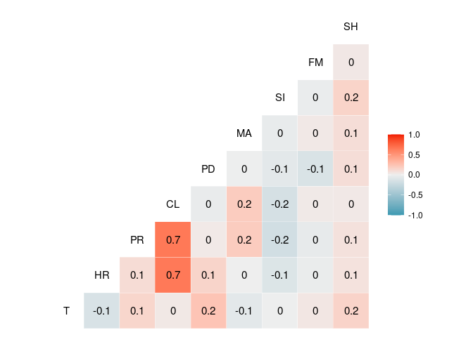

```r
ggcorr(data[2:10], palette = "RdBu", label = TRUE)
```

IL ressort de cette matrice de correlation que les variables sont globalement très peu linéairement corrélées entre elles sauf la couverture nuageuse **CL** qui est corrélée avec **PR** et **HR** comme nous l’avons vu.

### Variables explicatives et variable à expliquer

Nous allons dans cette partie étudiée la relation univariée entre chaque prédiacateur et la variable à expliquer.

#### Variables climatiques

```r
Liste_variables<-c(var_climat,var_socio_demo,var_socio_demo)
```

```r
plot_data_column = function (data, indice_var) {
ggplot(data)+
  geom_point(aes_string(y = "TDM", x = colnames(data)[indice_var]))+
  theme_minimal()
}
myplots <- lapply(var_climat, plot_data_column, data = data)
```

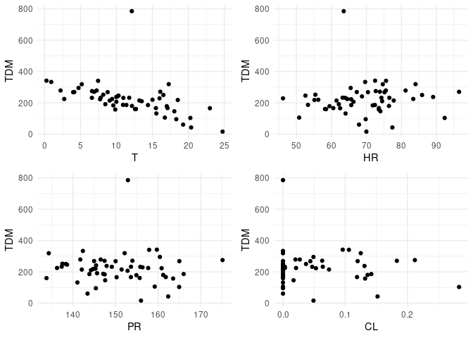

```r
grid.arrange( grobs = myplots, nrow = 2)
```

On remarque que le TDM décroit avec la température. En revanche pour les autres variables on ne peut rien dire. On peut voir ça grâce à une matrice de correlation.

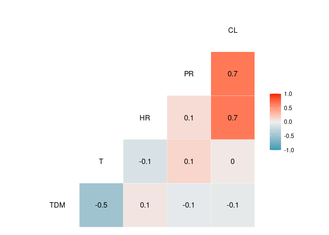

```r
ggcorr(data[c(1,var_climat)], palette = "RdBu", label = TRUE)
```

La variable à expliquer est donc négativement correlée avec la température.

#### Variables socio_démographiques

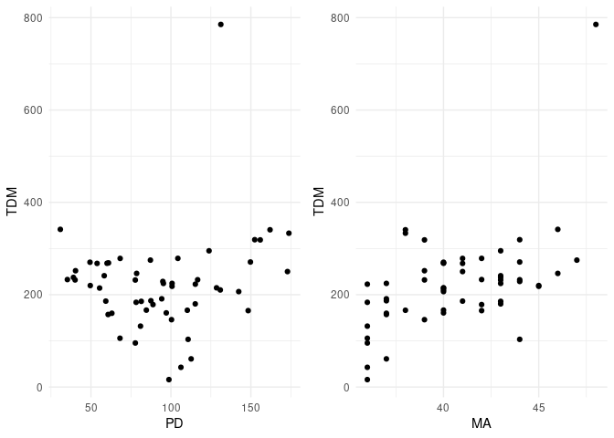

```r
myplots <- lapply(var_socio_demo, plot_data_column, data = data)
grid.arrange( grobs = myplots, nrow = 1)
```

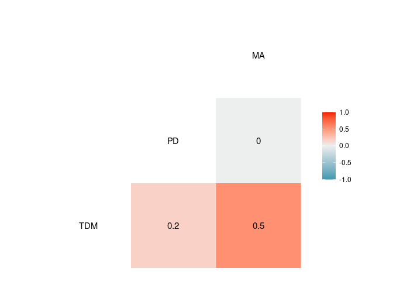

```r
c<-ggcorr(data[c(1,var_socio_demo)], palette = "RdBu", label = TRUE)
c
```

On remarque une légère correlation positive entre les variables socio-démographiques et la variables à expliquer. La variables **MA** est correlée plus significativement. et **PD** legèrement

#### Variables mesures gouvernementales

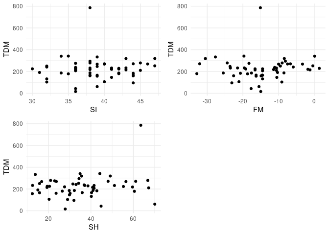

```r
myplots <- lapply(var_mes_gouv, plot_data_column, data = data)

grid.arrange( grobs = myplots, nrow = 2)
```

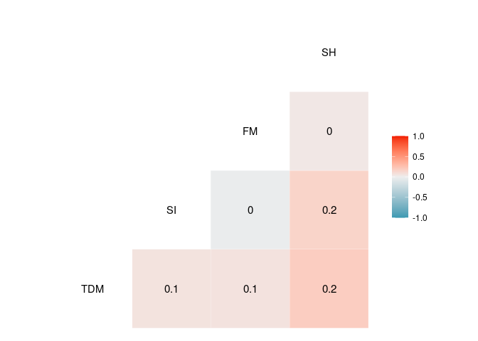

```r
c<-ggcorr(data[c(1,var_mes_gouv)], palette = "RdBu", label = TRUE)
c
```

Nous remarquons une très legère correlation linéaire entre notre variables à expliquer et les variables explicatives.

#### Toutes les variables

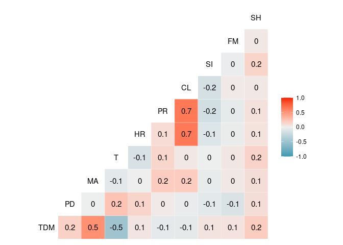

```r
ggcorr(data[c(1,var_socio_demo,var_climat,var_mes_gouv)], palette = "RdBu", label = TRUE)
```

### Resumé

Les seules variables linéairement corrélées avec la variable à expliquer sont l’âge médian et la temperature. On peut s’intéresser à l’effet joint des deux variables.

Nous allons faire un test de corellation pour confirmer ses observations.

```r
 cor_test<-function(var,list_test){
    c<-rep(c,length(list_test))
    p<-rep(c,length(list_test))

    for( test in 1:length(list_test)){
      c[i]<-  cor.test(data[var_pertinente], data["TDM"], method=c(list_test[test]))$estimate
      p[i]<-  cor.test(data[var_pertinente], data["TDM"], method=c(list_test[test]))$p.value
    }
    return (c,p)
 }
```

```r
c1<-  cor.test(data$MA, data$TDM, method=c("pearson"))$estimate
p1<-  cor.test(data$MA, data$TDM, method=c("pearson"))$p.value


c2<- cor.test(data$MA, data$TDM, method=c("kendall"))$estimate
p2<- cor.test(data$MA, data$TDM, method=c("kendall"))$p.value


c3<- cor.test(data$MA, data$TDM, method=c("spearman"))$estimate
p3<- cor.test(data$MA, data$TDM, method=c("spearman"))$p.value

MA_pvalue<-c(p1,p2,p3)
MA_cor<- c(c1,c2,c3)
```

```r
c1<-  cor.test(data$T, data$TDM, method=c("pearson"))$estimate
p1<-  cor.test(data$T, data$TDM, method=c("pearson"))$p.value


c2<- cor.test(data$T, data$TDM, method=c("kendall"))$estimate
p2<- cor.test(data$T, data$TDM, method=c("kendall"))$p.value


c3<- cor.test(data$T, data$TDM, method=c("spearman"))$estimate
p3<- cor.test(data$T, data$TDM, method=c("spearman"))$p.value

T_pvalue<-c(p1,p2,p3)
T_cor<- c(c1,c2,c3)
```

```r
Test<-as.data.frame(rbind("MA estimate"= MA_cor,"MA.pvalue"=MA_pvalue,"T estimate"=T_cor,"T.pvalue"=T_pvalue))
colnames(Test)<-c("pearson","kendall","spearman")
paged_table(Test)
```

|  | pearson | kendall | spearman |
| --- | --- | --- | --- |
| MA estimate | 5.317769e-01 | 3.568905e-01 | 4.883151e-01 |
| MA.pvalue | 2.941209e-05 | 2.107236e-04 | 1.554663e-04 |
| T estimate | -4.885019e-01 | -5.191919e-01 | -6.803030e-01 |
| T.pvalue | 1.544301e-04 | 2.179602e-08 | 3.707092e-08 |

Les 3 tests confirment la significativité de la correlation observée.

Nous allons créer deux nouvelles variables qualitatives pour modéliser cela. **T_cat** et **MA_cat**.

**T_cat**:

- “chaud” (T>=15)
- “froid” (T<10)
- “moyen”(10<=T <15)

Il n’est pas pertinent de diviser selon l’âge médian car ses pays ont une population avec un veillissement similaire.

```r
data<-data %>%
  mutate(
    T_cat = case_when(
      T<10 ~ "froid",
      T>=15 ~ "chaud",
      (T>=10 & T<15) ~ "moyen"
    )
  )
```

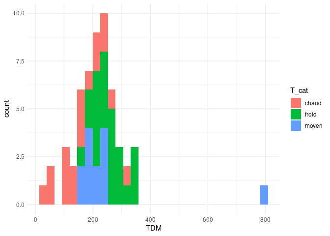

```r
ggplot(data) +
 aes(x = TDM, fill = T_cat) +
 geom_histogram(bins = 30L) +
 scale_fill_hue(direction = 1) +
 theme_minimal()
```

On confirmre à travers ce graphique que le **TDM** est correlée négativement avec la temperature (**T**).

Nous allons visualiser l’effet joint des deux variables sur **TDM**.

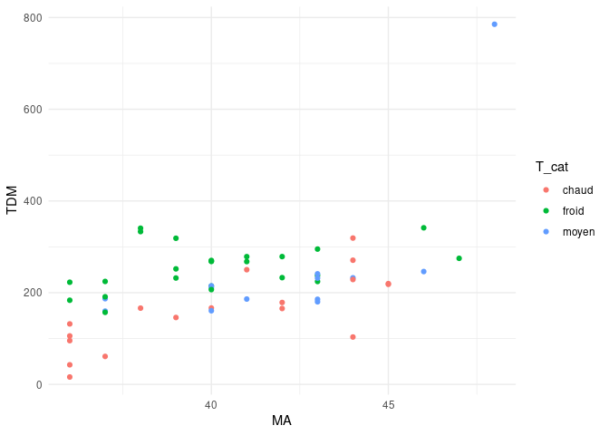

```r
ggplot(data) +
 aes(x = MA, y = TDM, colour = T_cat) +
 geom_point(shape = "circle", size = 1.5) +
 scale_color_hue(direction = 1) +
 theme_minimal()
```

On voit que indépendamment de la température le **TDM** a l’air de croitre légèrement avec l’âge médian **MA**.

### Test de linéarité

Dans la suite nous décidons de normaliser nos données comme suit:

$$X = \frac{X-X_{min}}{X_{max}-X_{min}}$$
.

```r
data<-data %>% select(-c("ID","T_cat"))
```

```r
 normalit<-function(m){
   (m - min(m))/(max(m)-min(m))
 }
```

```r
colnames(data)
```

```
##  [1] "TDM" "T"   "HR"  "PR"  "CL"  "PD"  "MA"  "SI"  "FM"  "SH"
```

```r
data<-data %>%
    mutate_each(list(normalit),TDM ,T ,  HR , PR , CL  ,PD  ,MA , SI , FM , SH )
```

```r
data_p<-data %>% mutate(T2=T**2,T3=T**3,HR2=HR**2,HR3=HR**3, PR2=PR**2,PR3=PR**3,CL2=CL**2,CL3=CL**3, PD2=PD**2, PD3=PD**3, MA2=MA**2,MA3=MA**3,SI2=SI**2,SI3=SI**3,FM2=FM**2,FM3=FM**3, SH2=SH**2,SH3=SH**3)
colnames(data_p)
```

```
##  [1] "TDM" "T"   "HR"  "PR"  "CL"  "PD"  "MA"  "SI"  "FM"  "SH"  "T2"  "T3"
## [13] "HR2" "HR3" "PR2" "PR3" "CL2" "CL3" "PD2" "PD3" "MA2" "MA3" "SI2" "SI3"
## [25] "FM2" "FM3" "SH2" "SH3"
```

```r
paged_table(data)
```

| TDM | T | HR | PR | CL | PD | MA | SI | FM | SH |
| --- | --- | --- | --- | --- | --- | --- | --- | --- | --- |
| 0.25776680 | 0.35877551 | 0.30397614 | 0.20038722 | 0.00000000 | 0.17180832 | 0.33333333 | 0.35294118 | 0.47521866 | 0.119584055 |
| 0.00000000 | 1.00000000 | 0.47355865 | 0.53678606 | 0.17314488 | 0.47513116 | 0.00000000 | 0.35294118 | 0.52186589 | 0.268630849 |
| 0.25841674 | 0.52775510 | 0.62902584 | 0.42666989 | 0.26148410 | 0.68345575 | 0.33333333 | 0.76470588 | 0.92419825 | 0.492201040 |
| 0.32718055 | 0.15142857 | 0.57654076 | 0.39254598 | 0.15547703 | 0.16075551 | 0.41666667 | 0.52941176 | 0.66763848 | 0.076256499 |
| 0.19563239 | 0.68734694 | 0.54453280 | 0.67763795 | 0.42049470 | 0.37628541 | 0.33333333 | 0.82352941 | 0.48396501 | 0.407279029 |
| 0.22033017 | 0.57632653 | 0.38767396 | 0.24370765 | 0.00000000 | 0.35410983 | 0.58333333 | 0.70588235 | 0.44606414 | 0.301559792 |
| 0.30417262 | 0.66408163 | 0.79005964 | 0.10963214 | 0.13074205 | 0.99384400 | 0.41666667 | 0.11764706 | 0.68221574 | 0.058925477 |
| 0.27076563 | 0.37265306 | 0.36520875 | 0.57768635 | 0.07420495 | 0.45092690 | 0.58333333 | 0.35294118 | 0.47521866 | 0.121317158 |
| 0.42181204 | 0.29306122 | 0.58528827 | 0.58325266 | 0.37455830 | 0.91745366 | 0.16666667 | 0.23529412 | 0.96209913 | 0.389948007 |
| 0.22098011 | 0.45387755 | 0.52226640 | 0.77904163 | 0.50176678 | 0.19888073 | 0.41666667 | 0.23529412 | 0.21574344 | 0.343154246 |

[output cut: 45 more lines]

```r
lm<-lm(formula = TDM~., data = data)
summary(lm)
```

```
##
## Call:
## lm(formula = TDM ~ ., data = data)
##
## Residuals:
##      Min       1Q   Median       3Q      Max
## -0.11797 -0.04922 -0.00079  0.03500  0.48334
##
## Coefficients:
##              Estimate Std. Error t value Pr(>|t|)
## (Intercept)  0.164476   0.084175   1.954  0.05694 .
## T           -0.328719   0.058659  -5.604 1.20e-06 ***
## HR           0.019571   0.105576   0.185  0.85377
## PR           0.009948   0.092327   0.108  0.91467
## CL          -0.093292   0.119631  -0.780  0.43957
## PD           0.154913   0.052826   2.933  0.00527 **
## MA           0.257108   0.047841   5.374 2.62e-06 ***
## SI           0.030263   0.050639   0.598  0.55309
## FM           0.066911   0.052964   1.263  0.21298
## SH           0.096250   0.048110   2.001  0.05149 .
## ---
## Signif. codes:  0 '***' 0.001 '**' 0.01 '*' 0.05 '.' 0.1 ' ' 1
##
## Residual standard error: 0.08925 on 45 degrees of freedom
## Multiple R-squared:  0.6438, Adjusted R-squared:  0.5726
## F-statistic: 9.037 on 9 and 45 DF,  p-value: 1.232e-07
```

Cet résultat confirme ce que nous avons vu prédemment. En effet, seulement **3** variables (**T**,**PD** et **MA**) sur les dix sont liées linéairement à **TDM** donc une hypothèse de linéarité entre nos prédicateurs n’est pas très appropriée. C’est dans ce sens que contrairement à l’étude *Tzampoglou P and Loukidis D. Investigation of the Importance of Climatic Factors in COVID-19 Worldwide Intensity. Int.J. Environ. Res. Public Health (2020)*, nous décidons de faire **une hypothèse polynomiale en considerant pour chaque variable $X$,deux novelles variables $X^2$ et $X^3$**.

### Données

```r
data_p<-data %>% mutate(T2=T**2,T3=T**3,Hr2=HR**2,HR3=HR**3, Pr2=PR**2,PR3=PR**3,CL2=CL**2,CL3=CL**3, PD2=PD**2, PD3=PD**3, MA2=MA**2,MA3=MA**3,SI2=SI**2,SI3=SI**3,FM2=FM**2,FM3=FM**3, SH2=SH**2,SH3=SH**3)
paged_table(data_p)
```

| TDM | T | HR | PR | CL | PD | MA | SI | FM | SH | T2 | T3 | Hr2 | HR3 | Pr2 | PR3 | CL2 | CL3 | PD2 | PD3 | MA2 | MA3 | SI2 | SI3 | FM2 | FM3 | SH2 | SH3 |
| --- | --- | --- | --- | --- | --- | --- | --- | --- | --- | --- | --- | --- | --- | --- | --- | --- | --- | --- | --- | --- | --- | --- | --- | --- | --- | --- | --- |
| 0.25776680 | 0.35877551 | 0.30397614 | 0.20038722 | 0.00000000 | 0.17180832 | 0.33333333 | 0.35294118 | 0.47521866 | 0.119584055 | 0.1287198667 | 4.618154e-02 | 0.092401496 | 0.0280878503 | 0.0401550386 | 8.046557e-03 | 0.000000000 | 0.000000e+00 | 0.029518100 | 5.071455e-03 | 0.111111111 | 0.0370370370 | 0.124567474 | 0.0439649908 | 0.225832774 | 1.073199e-01 | 1.430035e-02 | 1.710093e-03 |
| 0.00000000 | 1.00000000 | 0.47355865 | 0.53678606 | 0.17314488 | 0.47513116 | 0.00000000 | 0.35294118 | 0.52186589 | 0.268630849 | 1.0000000000 | 1.000000e+00 | 0.224257793 | 0.1061992174 | 0.2881392742 | 1.546691e-01 | 0.029979148 | 5.190736e-03 | 0.225749624 | 1.072607e-01 | 0.000000000 | 0.0000000000 | 0.124567474 | 0.0439649908 | 0.272344006 | 1.421270e-01 | 7.216253e-02 | 1.938508e-02 |
| 0.25841674 | 0.52775510 | 0.62902584 | 0.42666989 | 0.26148410 | 0.68345575 | 0.33333333 | 0.76470588 | 0.92419825 | 0.492201040 | 0.2785254477 | 1.469932e-01 | 0.395673514 | 0.2488888662 | 0.1820471980 | 7.767406e-02 | 0.068373934 | 1.787870e-02 | 0.467111767 | 3.192502e-01 | 0.111111111 | 0.0370370370 | 0.584775087 | 0.4471809485 | 0.854142407 | 7.893969e-01 | 2.422619e-01 | 1.192415e-01 |
| 0.32718055 | 0.15142857 | 0.57654076 | 0.39254598 | 0.15547703 | 0.16075551 | 0.41666667 | 0.52941176 | 0.66763848 | 0.076256499 | 0.0229306122 | 3.472350e-03 | 0.332399243 | 0.1916417105 | 0.1540923484 | 6.048833e-02 | 0.024173107 | 3.758363e-03 | 0.025842334 | 4.154297e-03 | 0.173611111 | 0.0723379630 | 0.280276817 | 0.1483818441 | 0.445741145 | 2.975939e-01 | 5.815054e-03 | 4.434356e-04 |
| 0.19563239 | 0.68734694 | 0.54453280 | 0.67763795 | 0.42049470 | 0.37628541 | 0.33333333 | 0.82352941 | 0.48396501 | 0.407279029 | 0.4724458142 | 3.247342e-01 | 0.296515974 | 0.1614626744 | 0.4591931882 | 3.111667e-01 | 0.176815792 | 7.435010e-02 | 0.141590713 | 5.327852e-02 | 0.111111111 | 0.0370370370 | 0.678200692 | 0.5585182170 | 0.234222135 | 1.133553e-01 | 1.658762e-01 | 6.755790e-02 |
| 0.22033017 | 0.57632653 | 0.38767396 | 0.24370765 | 0.00000000 | 0.35410983 | 0.58333333 | 0.70588235 | 0.44606414 | 0.301559792 | 0.3321522699 | 1.914282e-01 | 0.150291096 | 0.0582639439 | 0.0593934175 | 1.447463e-02 | 0.000000000 | 0.000000e+00 | 0.125393771 | 4.440317e-02 | 0.340277778 | 0.1984953704 | 0.498269896 | 0.3517199267 | 0.198973217 | 8.875482e-02 | 9.093831e-02 | 2.742334e-02 |
| 0.30417262 | 0.66408163 | 0.79005964 | 0.10963214 | 0.13074205 | 0.99384400 | 0.41666667 | 0.11764706 | 0.68221574 | 0.058925477 | 0.4410044148 | 2.928629e-01 | 0.624194238 | 0.4931506764 | 0.0120192060 | 1.317691e-03 | 0.017093483 | 2.234837e-03 | 0.987725899 | 9.816455e-01 | 0.173611111 | 0.0723379630 | 0.013840830 | 0.0016283330 | 0.465418321 | 3.175157e-01 | 3.472212e-03 | 2.046017e-04 |
| 0.27076563 | 0.37265306 | 0.36520875 | 0.57768635 | 0.07420495 | 0.45092690 | 0.58333333 | 0.35294118 | 0.47521866 | 0.121317158 | 0.1388703040 | 5.175044e-02 | 0.133377429 | 0.0487106039 | 0.3337215195 | 1.927864e-01 | 0.005506374 | 4.086002e-04 | 0.203335067 | 9.168925e-02 | 0.340277778 | 0.1984953704 | 0.124567474 | 0.0439649908 | 0.225832774 | 1.073199e-01 | 1.471785e-02 | 1.785528e-03 |
| 0.42181204 | 0.29306122 | 0.58528827 | 0.58325266 | 0.37455830 | 0.91745366 | 0.16666667 | 0.23529412 | 0.96209913 | 0.389948007 | 0.0858848813 | 2.516953e-02 | 0.342562359 | 0.2004977309 | 0.3401836679 | 1.984130e-01 | 0.140293923 | 5.254825e-02 | 0.841721209 | 7.722402e-01 | 0.027777778 | 0.0046296296 | 0.055363322 | 0.0130266640 | 0.925634727 | 8.905524e-01 | 1.520594e-01 | 5.929528e-02 |
| 0.22098011 | 0.45387755 | 0.52226640 | 0.77904163 | 0.50176678 | 0.19888073 | 0.41666667 | 0.23529412 | 0.21574344 | 0.343154246 | 0.2060048313 | 9.350097e-02 | 0.272762194 | 0.1424545297 | 0.6069058556 | 4.728049e-01 | 0.251769906 | 1.263298e-01 | 0.039553544 | 7.866438e-03 | 0.173611111 | 0.0723379630 | 0.055363322 | 0.0130266640 | 0.046545232 | 1.004183e-02 | 1.177548e-01 | 4.040807e-02 |

[output cut: 45 more lines]

### Modèle

Soit **$\mathcal{X}$** l’ensemble des prédicteurs et **$n$** le nombre de prédicteurs, nous avons donc cette nouvelle formulation du modèle: